# Exercise 11

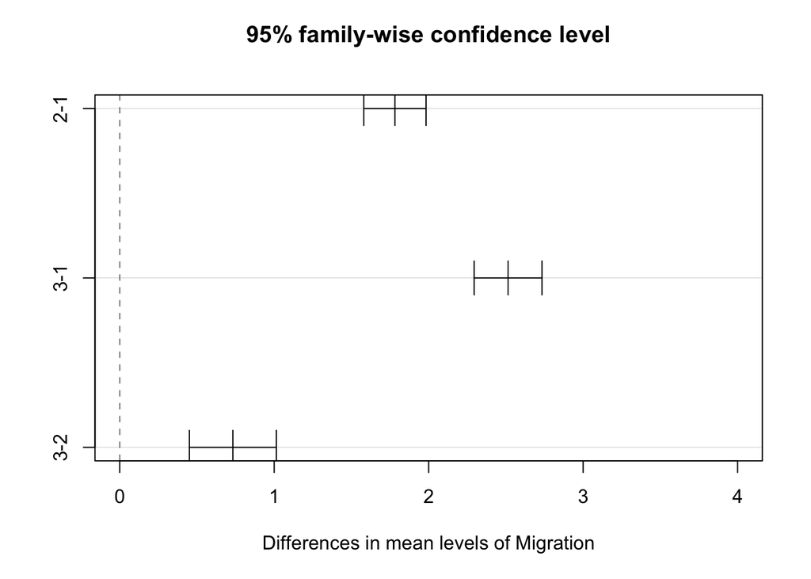

none of the CI’s cross 0!! so there is a signifcant difference between each of the migration types

STEP 4–>

Winnow your original data to just consider birds from the Infraorder “Passeriformes” (song birds).

Run separate one-factor ANOVA analyses to look at the association between [1] relative beak length and Primary.Lifestyle [2] relative beak length and Trophic.Level.

Make boxplots of response variable by each predictor and by the combination of predictors.

Run linear models for each predictor separately and interpret the model output.

winnowing the data to ONLY consider passeriformes

```r
passeriformes <- d_filtered %>%
  filter(Order1 == "Passeriformes")
```

run anova b/t rel_Beak and Primary.Lifestyle, then rel_Beak and Trophic.Level

```r
# m4- rel_Beak (y) and Primary.Lifestyle (x)
m4_anova <- aov(rel_Beak ~ Primary.Lifestyle, data = passeriformes)
summary(m4_anova)
```

```
##                     Df Sum Sq Mean Sq F value Pr(>F)
## Primary.Lifestyle    3  17.94   5.981   128.9 <2e-16 ***
## Residuals         6602 306.26   0.046
## ---
## Signif. codes:  0 '***' 0.001 '**' 0.01 '*' 0.05 '.' 0.1 ' ' 1
```

```r
# m5- rel_Beak (y) and Trophic.Level (x)
m5_anova <- aov(rel_Beak ~ Trophic.Level, data = passeriformes)
summary(m5_anova)
```

```
##                 Df Sum Sq Mean Sq F value Pr(>F)
## Trophic.Level    2  16.26   8.129   174.3 <2e-16 ***
## Residuals     6603 307.95   0.047
## ---
## Signif. codes:  0 '***' 0.001 '**' 0.01 '*' 0.05 '.' 0.1 ' ' 1
```

make boxplots of response variable by predictor AND combination of predictors

for individual predictors

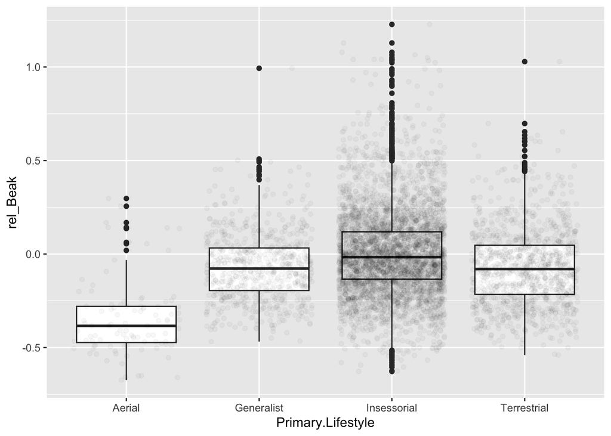

```r
# rel_Beak (y) and Primary.Lifestyle (x)
ggplot(data = passeriformes, aes(y = rel_Beak, x = Primary.Lifestyle)) + geom_boxplot() + geom_jitter(position = "jitter", alpha = 0.03)
```

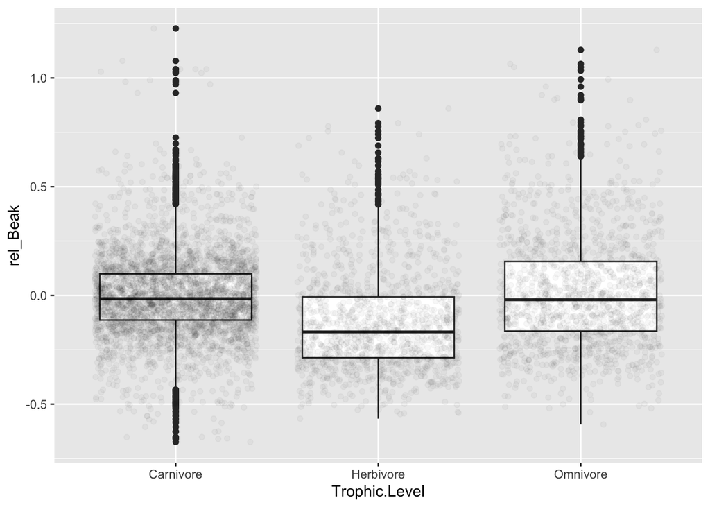

```r
# rel_Beak (y) and Trophic.Level (x)
# adjust angle of x-ticks to better see each word
ggplot(data = passeriformes, aes(y = rel_Beak, x = Trophic.Level)) + geom_boxplot() + geom_jitter(position = "jitter", alpha = 0.03)
```

combined predictors: I looked at Module 20.8

uses facet_wrap() function

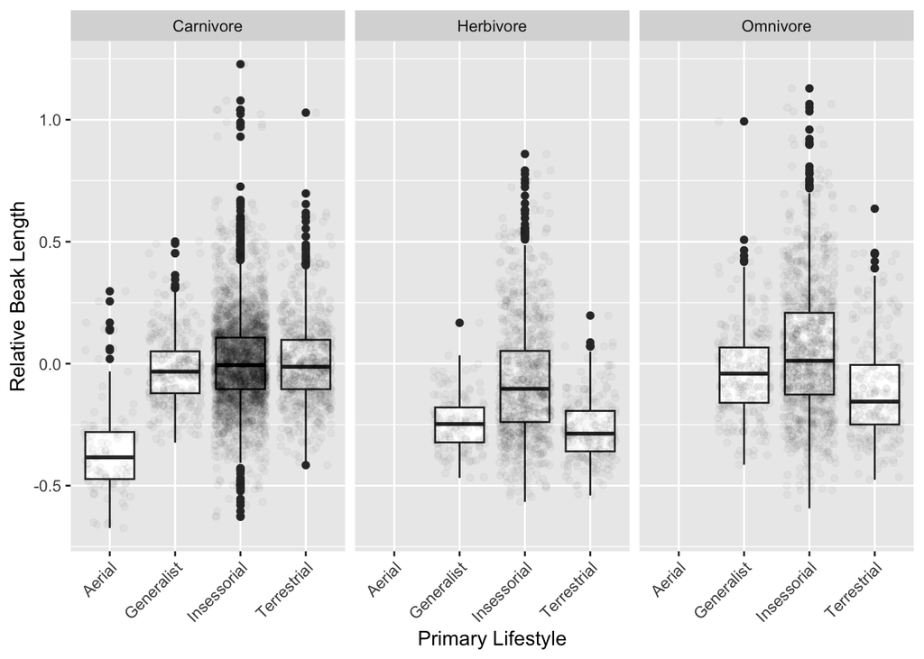

```r
# rel_Beak (y) and Primary.Lifestyle (x)
# Trophic.Level is facet wrapped
ggplot(data = passeriformes, aes(y = rel_Beak, x = Primary.Lifestyle)) + geom_boxplot() + theme(axis.text.x = element_text(angle = 45, hjust = 1)) + #needed to rotate x-labels to fit in the full text
  facet_wrap(~ Trophic.Level, ncol=3) + # 3 levels (carnivore, herbivore, omnivore)
  xlab("Primary Lifestyle") + ylab("Relative Beak Length") + geom_jitter(position = "jitter", alpha = 0.03)
```

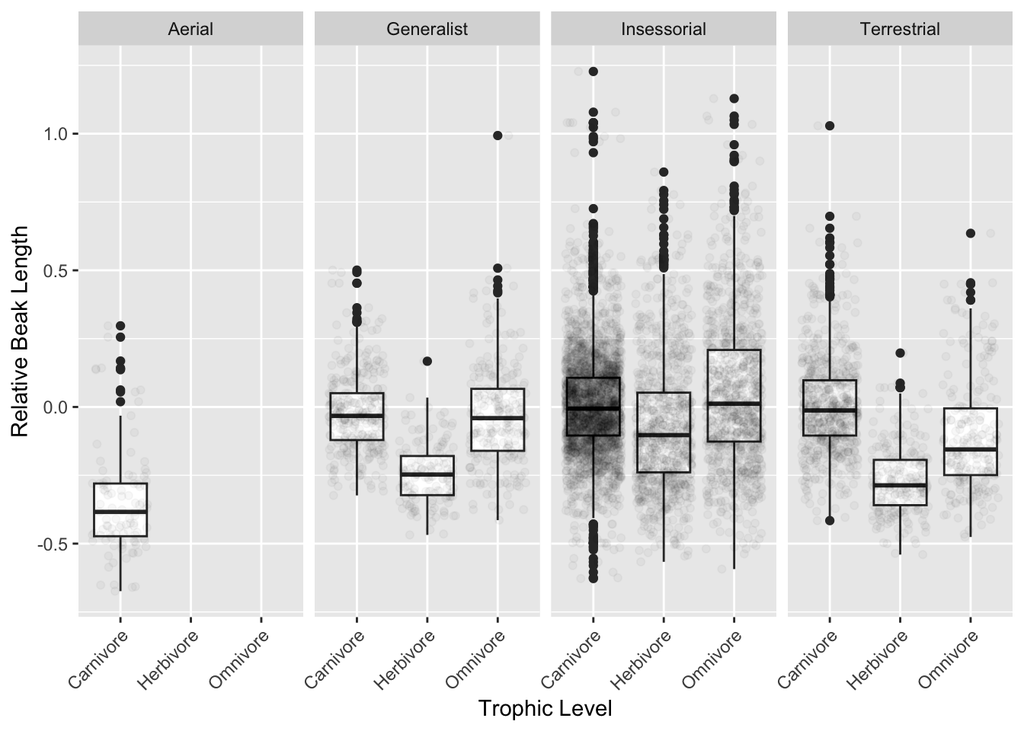

```r
# rel_Beak (y) and Trophic.Level (x)
# Primary.Lifestyle is facet wrapped
ggplot(data = passeriformes, aes(y = rel_Beak, x = Trophic.Level)) + geom_boxplot() + theme(axis.text.x = element_text(angle = 45, hjust = 1)) + #needed to rotate x-labels to fit in the full text
  facet_wrap(~ Primary.Lifestyle, ncol=4) + # 4 levels (aerial, generalist, insessorial, terrestrial)
  xlab("Trophic Level") + ylab("Relative Beak Length") + geom_jitter(position = "jitter", alpha = 0.03)
```

run linear models (lm) b/t rel_Beak and Primary.Lifestyle, then rel_Beak and Trophic.Level

```r
# m4- rel_Beak (y) and Primary.Lifestyle (x)
m4_lm <- lm(rel_Beak ~ Primary.Lifestyle, data = passeriformes)
summary(m4_lm)
```

```
##
## Call:
## lm(formula = rel_Beak ~ Primary.Lifestyle, data = passeriformes)
##
## Residuals:
##      Min       1Q   Median       3Q      Max
## -0.63098 -0.13765 -0.01698  0.11201  1.22436
##
## Coefficients:
##                              Estimate Std. Error t value Pr(>|t|)
## (Intercept)                  -0.34896    0.02165  -16.12   <2e-16 ***
## Primary.LifestyleGeneralist   0.27858    0.02312   12.05   <2e-16 ***
## Primary.LifestyleInsessorial  0.35225    0.02188   16.10   <2e-16 ***
## Primary.LifestyleTerrestrial  0.27838    0.02255   12.35   <2e-16 ***
## ---
## Signif. codes:  0 '***' 0.001 '**' 0.01 '*' 0.05 '.' 0.1 ' ' 1
##
## Residual standard error: 0.2154 on 6602 degrees of freedom
## Multiple R-squared:  0.05534,    Adjusted R-squared:  0.05492
## F-statistic: 128.9 on 3 and 6602 DF,  p-value: < 2.2e-16
```

```r
# m5- rel_Beak (y) and Trophic.Level (x)
m5_lm <- lm(rel_Beak ~ Trophic.Level, data = passeriformes)
summary(m5_lm)
```

```
##
## Call:
## lm(formula = rel_Beak ~ Trophic.Level, data = passeriformes)
##
## Residuals:
##      Min       1Q   Median       3Q      Max
## -0.67028 -0.13672 -0.02056  0.11134  1.23126
##
## Coefficients:
##                         Estimate Std. Error t value Pr(>|t|)
## (Intercept)            -0.003606   0.003495  -1.032  0.30213
## Trophic.LevelHerbivore -0.118573   0.006940 -17.084  < 2e-16 ***
## Trophic.LevelOmnivore   0.017822   0.006596   2.702  0.00691 **
## ---
## Signif. codes:  0 '***' 0.001 '**' 0.01 '*' 0.05 '.' 0.1 ' ' 1
##
## Residual standard error: 0.216 on 6603 degrees of freedom
## Multiple R-squared:  0.05015,    Adjusted R-squared:  0.04986
## F-statistic: 174.3 on 2 and 6603 DF,  p-value: < 2.2e-16
```

from the results of the linear modeling/ANOVA, we can see that both of the F-stats are high enough (and their p-values low enough) to suggest a significant relationship between relative beak length and BOTH trophic level and primary lifestyle in passeriformes. based on the R^2 values we also see there percentage of variance that is significantly related is around 5% for both

[output not shown]

STEP 7–>

Use the interaction.plot() function to visualize the interaction between Primary.Lifestyle and Trophic.Level

once again, the code for this is influenced by the instructions in Module 20.8

the x factor is primary lifestyle and trace factor is trophic level

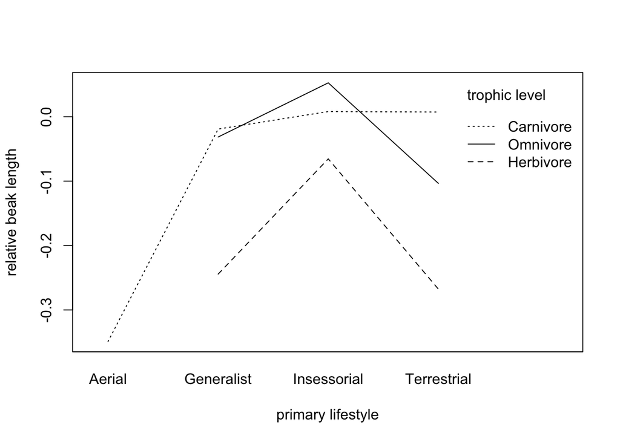

```r
interaction.plot(
  x.factor = passeriformes$Primary.Lifestyle,
  xlab = "primary lifestyle",
  trace.factor = passeriformes$Trophic.Level,
  trace.label = "trophic level",
  response = passeriformes$rel_Beak,
  fun = base::mean, # make sure we use {base} version
  ylab = "relative beak length"
)
```

just switching the x factor to trophic level and trace to primary lifestyle

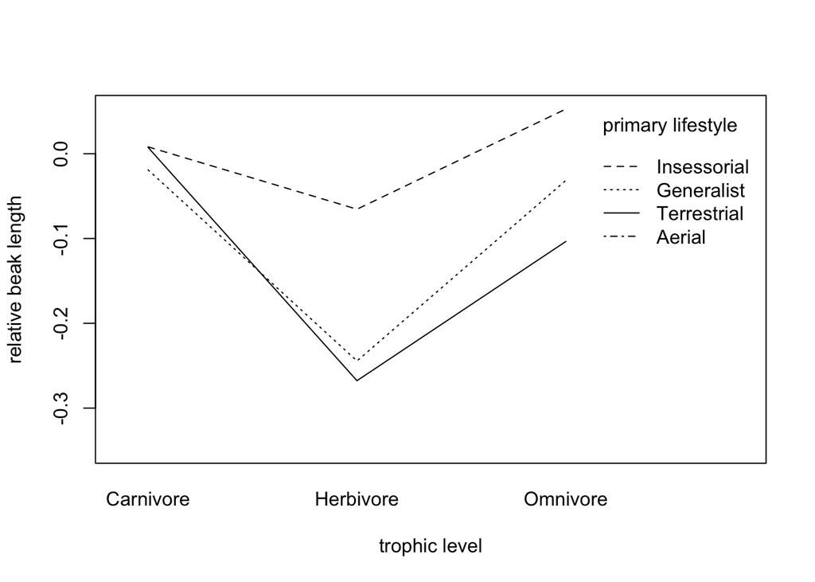

```r
interaction.plot(
  trace.factor = passeriformes$Primary.Lifestyle,
  trace.label = "primary lifestyle",
  x.factor = passeriformes$Trophic.Level,
  xlab = "trophic level",
  response = passeriformes$rel_Beak,
  fun = base::mean, # make sure we use {base} version
  ylab = "relative beak length"
)
```